# Newton Raphson for Optimization, Attempt 3

March 2, 2018

## Exponential Model Example

Model: \(X_1, \ldots, X_n \sim \text{Exp}(\lambda)\)

Example: \(X_i\) is a waiting time in minutes for individual \(i\) who goes to the emergency room. \(\lambda\) is the number of patients they see per minute, on average.

\[ \begin{align*} f(x_i | \lambda) &= \lambda e^{-\lambda x_i} \\ L(\lambda | x_1, \ldots, x_n) &= \, \cdots \, = n \log(\lambda) - \lambda \sum_{i = 1}^n x_i \\ \frac{d}{d \lambda} L(\lambda | x_1, \ldots, x_n) &= \frac{n}{\lambda} - \sum_{i = 1}^n x_i \\ \frac{d^2}{d \lambda^2} L(\lambda | x_1, \ldots, x_n) &= \frac{-n}{\lambda^2} \end{align*} \]

## Log-likelihood function, maximum likelihood estimate

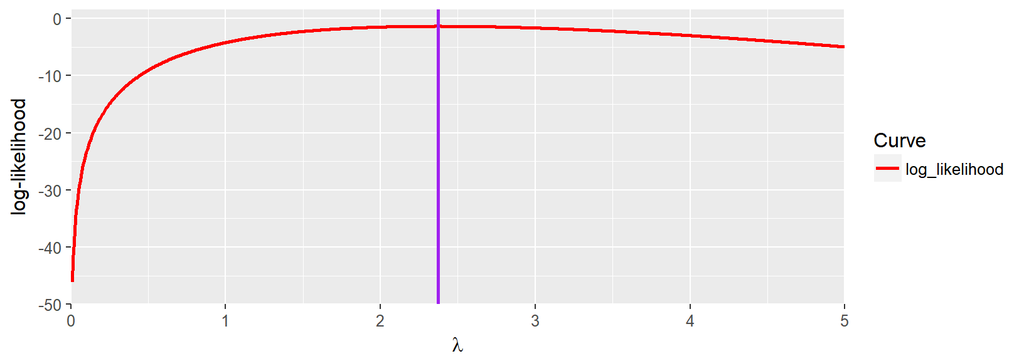

The purple line is at the MLE.

…But what if we couldn't solve for the MLE directly?

## Taylor Series Approximation to \(L\)

Pick a value \(\lambda_0\). The second-order Taylor Series approximation to \(L(\lambda | x_1, \ldots, x_n)\) around \(\lambda_0\) is

\[ \begin{align*} P_2(\lambda) &= L(\lambda_0 | x_1, \ldots, x_n) + \frac{d}{d\lambda} L(\lambda_0 | x_1, \ldots, x_n)(\lambda -\lambda_0) \\ &\qquad + \frac{1}{2} \frac{d^2}{d\lambda^2} L(\lambda_0 | x_1, \ldots, x_n)(\lambda -\lambda_0)^2 \\ \end{align*} \]

The maximum of \(P_2(\lambda)\) is at \(\lambda_{1} = \lambda_0 - \frac{\frac{d}{d\lambda} L(\lambda_0 | x_1, \ldots, x_n)}{\frac{d^2}{d\lambda^2} L(\lambda_0 | x_1, \ldots, x_n)}\)

Now repeat, but centering the Taylor Series approximation at \(\lambda_1\).

## Pick \(\lambda_0\)

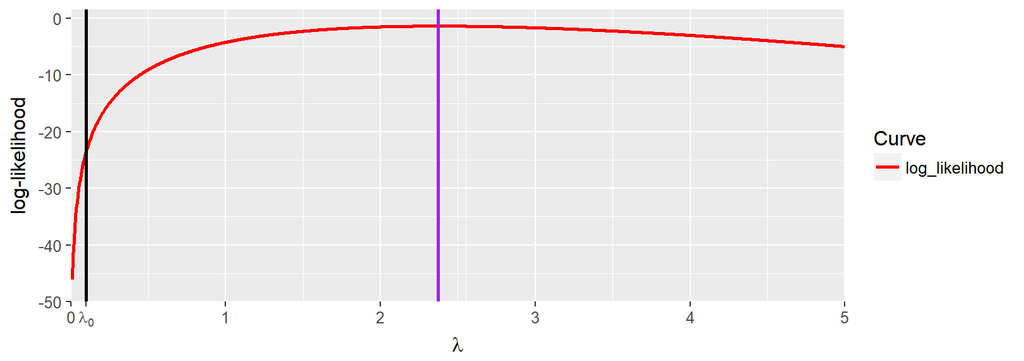

\[\lambda_0 = 0.1\]

## Approximate \(L\) around \(\lambda_0\), get \(\lambda_1\)

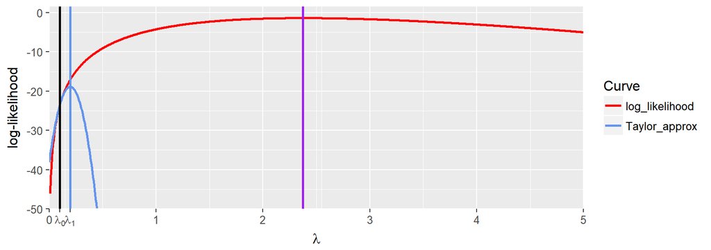

\[\lambda_0 = 0.1 \text{, } \lambda_1 = \lambda_0 - \frac{\frac{d}{d\lambda} L(\lambda_0 | x_1, \ldots, x_n)}{\frac{d^2}{d\lambda^2} L(\lambda_0 | x_1, \ldots, x_n)} = 0.196\]

## Approximate \(L\) around \(\lambda_1\), get \(\lambda_2\)

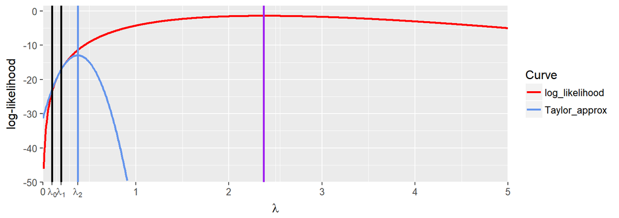

\[\lambda_0 = 0.1, \, \lambda_1 = 0.196,\] \[\lambda_2 = \lambda_1 - \frac{\frac{d}{d\lambda} L(\lambda_1 | x_1, \ldots, x_n)}{\frac{d^2}{d\lambda^2} L(\lambda_1 | x_1, \ldots, x_n)} = 0.375\]

## Approximate \(L\) around \(\lambda_2\), get \(\lambda_3\)

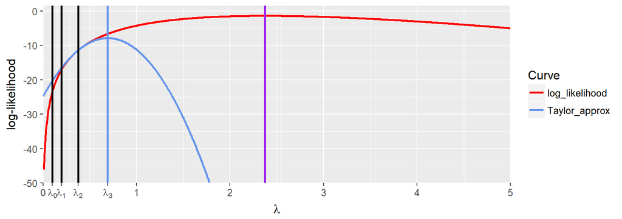

\[\lambda_0 = 0.1, \, \lambda_1 = 0.196, \lambda_2 = 0.375\] \[\lambda_3 = \lambda_2 - \frac{\frac{d}{d\lambda} L(\lambda_2 | x_1, \ldots, x_n)}{\frac{d^2}{d\lambda^2} L(\lambda_2 | x_1, \ldots, x_n)} = 0.691\]

## Approximate \(L\) around \(\lambda_3\), get \(\lambda_4\)

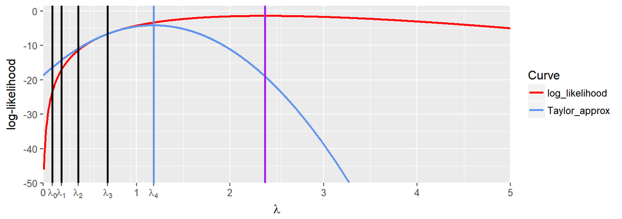

\[\lambda_0 = 0.1, \, \lambda_1 = 0.196, \lambda_2 = 0.375, \lambda_3 = 0.691\] \[\lambda_4 = \lambda_3 - \frac{\frac{d}{d\lambda} L(\lambda_3 | x_1, \ldots, x_n)}{\frac{d^2}{d\lambda^2} L(\lambda_3 | x_1, \ldots, x_n)} = 1.181\]

## Approximate \(L\) around \(\lambda_4\), get \(\lambda_5\)

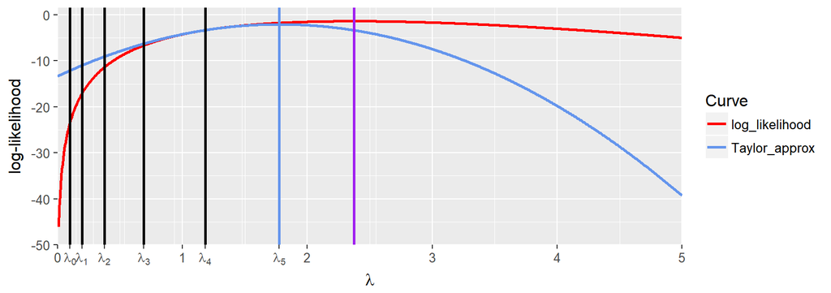

\[\lambda_0 = 0.1, \, \lambda_1 = 0.196, \lambda_2 = 0.375, \lambda_3 = 0.691, \lambda_4 = 1.181\] \[\lambda_5 = \lambda_4 - \frac{\frac{d}{d\lambda} L(\lambda_4 | x_1, \ldots, x_n)}{\frac{d^2}{d\lambda^2} L(\lambda_4 | x_1, \ldots, x_n)} = 1.775\]

## Approximate \(L\) around \(\lambda_5\), get \(\lambda_6\)

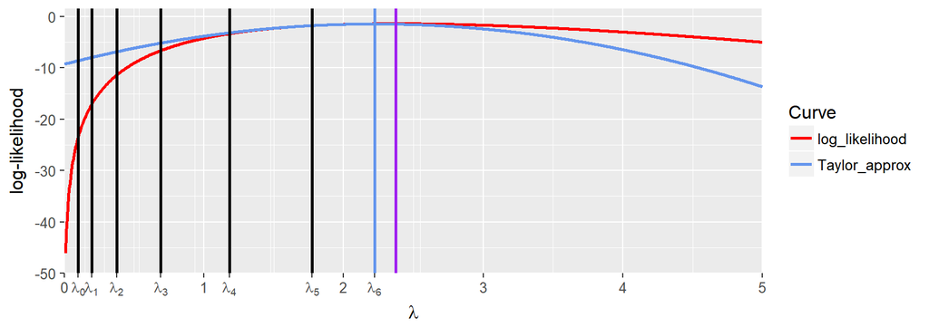

\[\lambda_0 = 0.1, \, \lambda_1 = 0.196, \lambda_2 = 0.375, \lambda_3 = 0.691, \lambda_4 = 1.181\] \[\lambda_5 = 1.775, \, \lambda_6 = \lambda_5 - \frac{\frac{d}{d\lambda} L(\lambda_5 | x_1, \ldots, x_n)}{\frac{d^2}{d\lambda^2} L(\lambda_5 | x_1, \ldots, x_n)} = 2.223\]